# CB1 - Rainbow Reading

Author

Ben Jacobs

Published

July 22, 2025

# Does Letter and Background Color Have an Effect on Reading Speed?

## Introduction

Most reading we do is in a basic sans or serif font with near-black text and a near-white background. It’s obvious that distracting colors can make it more difficult to read text, but does it significantly affect reading speed? In this study, participants were given three paragraphs of text to read, each selected from a different public domain book: *Vanity Fair* by William Makepeace Thackeray, *Northanger Abbey* by Jane Austen, and *The Pickwick Papers* by Charles Dickens. One paragraph was colored black and white, one was colored with rainbow text on a white background, and the third was with multicolored-text over a multicolored background.

## Hypothesis

“This study used a complete block design, where each participant was exposed to all three color conditions, controlling for individual reading speed differences.”

### Model

This is the model for the study:

$$Y_{ij} = \mu + \alpha_{i} + \beta_{j} + \varepsilon_{ij} \\
\text{or} \\
Y_{ij} = \mu + \alpha_{Participant} + \beta_{ColorCondition} + \varepsilon_{ij}$$

Where - $Y_{ij}$: Speed in seconds for participant $i$ under color condition $j$ - $\mu$: Overall intercept (grand mean) - $\alpha_i$: Effect of the Participant (blocking effect) - $\beta_j$: Effect of Color Condition (treatment effect) - $\varepsilon_{ij}$: Residual error

The null hypothesis for the study is that the changing of color condition has no effect on reading speed. The alternative hypothesis for the study is that the changing of color condition has an effect on reading speed.

$$\begin{aligned}
H_0 &: \beta_j = 0 \quad \text{for all conditions} \\
H_A &: \beta_j \neq 0 \quad \text{for some j}
\end{aligned}$$

### Alpha

An alpha level of 0.05 was selected to reflect a conventional significance threshold, as neither Type I nor Type II errors were deemed to carry substantially greater consequences in the context of this study.

$$\alpha = 0.05$$

## Methods

The paragraphs were presented to the participants in a random order. Participants indicated they had started reading, and a timer was started. When participants indicated they were finished, the timer was stopped. Results were recorded after each paragraph.

#### Pictures

[figure not shown]

[figure not shown]

[figure not shown]

#### Code for colored text only

```
        function rainbowLetters() {
          const body = DocumentApp.getActiveDocument().getBody();
          const text = body.editAsText();
          const fullText = text.getText();

          for (let i = 0; i < fullText.length; i++) {
            const char = fullText.charAt(i);
            if (char !== ' ' && char !== '\n') {
              const color = getRandomDarkVibrantColor();
              text.setForegroundColor(i, i, color);
            }
          }
        }

        function getRandomVibrantColor() {
          // Random hue (0–360), high saturation (70–100%), dark lightness (10–40%)
          const h = Math.floor(Math.random() * 360);
          const s = Math.floor(Math.random() * 31) + 70;  // 70–100%
          const l = Math.floor(Math.random() * 31) + 20;  // 10–40% for darker tone
          return hslToHex(h, s, l);
        }

        function hslToHex(h, s, l) {
          s /= 100;
          l /= 100;

          const c = (1 - Math.abs(2 * l - 1)) * s;
          const x = c * (1 - Math.abs((h / 60) % 2 - 1));
          const m = l - c / 2;
          let r = 0, g = 0, b = 0;

          if (h < 60) [r, g, b] = [c, x, 0];
          else if (h < 120) [r, g, b] = [x, c, 0];
          else if (h < 180) [r, g, b] = [0, c, x];
          else if (h < 240) [r, g, b] = [0, x, c];
          else if (h < 300) [r, g, b] = [x, 0, c];
          else [r, g, b] = [c, 0, x];

          r = Math.round((r + m) * 255);
          g = Math.round((g + m) * 255);
          b = Math.round((b + m) * 255);

          return rgbToHex(r, g, b);
        }

        function rgbToHex(r, g, b) {
          return (
            "#" +
            [r, g, b]
              .map(x => x.toString(16).padStart(2, '0'))
              .join('')
          );
        }
```

#### Code for colored text and background

```
        function rainbowLettersMixedLightness() {
          const body = DocumentApp.getActiveDocument().getBody();
          const text = body.editAsText();
          const fullText = text.getText();

          for (let i = 0; i < fullText.length; i++) {
            const char = fullText.charAt(i);
            if (char !== ' ' && char !== '\n') {
              // Randomly decide: light text on dark bg OR dark text on light bg
              const isLightText = Math.random() < 0.5;

              const textHSL = isLightText ? getRandomLightHSL() : getRandomDarkHSL();

              let bgHSL, contrast, attempts = 0;

              // Generate background color with opposite lightness
              do {
                bgHSL = isLightText ? getRandomDarkHSL() : getRandomLightHSL();

                const textLum = getLuminance(textHSL.h, textHSL.s, textHSL.l);
                const bgLum = getLuminance(bgHSL.h, bgHSL.s, bgHSL.l);
                contrast = getContrastRatio(textLum, bgLum);

                attempts++;
              } while (contrast < 2.0 && attempts < 30); // adjust 2.0 for stricter contrast

              const textColor = hslToHex(textHSL.h, textHSL.s, textHSL.l);
              const bgColor = hslToHex(bgHSL.h, bgHSL.s, bgHSL.l);

              text.setForegroundColor(i, i, textColor);
              text.setBackgroundColor(i, i, bgColor);
            }
          }
        }

        function getRandomLightHSL() {
          return {
            h: Math.floor(Math.random() * 360),
            s: Math.floor(Math.random() * 31) + 70, // 70–100%
            l: Math.floor(Math.random() * 21) + 80  // 80–100%
```

[output cut: 43 more lines]

```
          const g = parseInt(hex.substr(3, 2), 16) / 255;
          const b = parseInt(hex.substr(5, 2), 16) / 255;

          const [R, G, B] = [r, g, b].map(c =>
            c <= 0.03928 ? c / 12.92 : Math.pow((c + 0.055) / 1.055, 2.4)
          );

          return 0.2126 * R + 0.7152 * G + 0.0722 * B;
        }

        function getContrastRatio(lum1, lum2) {
          const L1 = Math.max(lum1, lum2);
          const L2 = Math.min(lum1, lum2);
          return (L1 + 0.05) / (L2 + 0.05);
        }
```

## Data

```r
pacman::p_load(tidyverse,dplyr,car,readr,purrr,broom,mosaic,pander,ggplot2,lubridate,vroom,ggformula,patchwork,emmeans)
```

```r
rr <- read_csv("rainbowreading.csv")
rr <- pivot_longer(rr, cols = BW:CC, names_to = "ColorCondition", values_to = "Seconds")
rr$ColorCondition <- factor(rr$ColorCondition, levels = c("BW", "CW", "CC"))
```

Let’s take a look at the data. Here, ‘BW’ refers to black text on a white background, ‘CW’ refers to colored text over a white background, and ‘CC’ refers to colored text over a colored background.

```r
rr %>%
  knitr::kable(caption = "Survey Responses")
```

Survey Responses

| Individual | ColorCondition | Seconds |
| --- | --- | --- |
| A | BW | 31 |
| A | CW | 30 |
| A | CC | 57 |
| B | BW | 50 |
| B | CW | 62 |
| B | CC | 63 |
| C | BW | 78 |
| C | CW | 76 |
| C | CC | 79 |
| D | BW | 47 |
| D | CW | 43 |
| D | CC | 68 |

### Numerical Analysis

The table below shows the sample size, mean, and standard deviation for each passage:

```r
# Summary by ColorCondition
rr_summary <- rr %>%
  group_by(ColorCondition) %>%
  summarise(
    N = n(),
    Mean_Time = mean(Seconds, na.rm = TRUE),
    SD_Time = sd(Seconds, na.rm = TRUE)
  )

# Display the summary table
knitr::kable(rr_summary, digits = 2, caption = "Summary of Response Time (Seconds) by Color Condition")
```

Summary of Response Time (Seconds) by Color Condition

| ColorCondition | N | Mean_Time | SD_Time |
| --- | --- | --- | --- |
| BW | 4 | 51.50 | 19.54 |
| CW | 4 | 52.75 | 20.32 |
| CC | 4 | 66.75 | 9.32 |

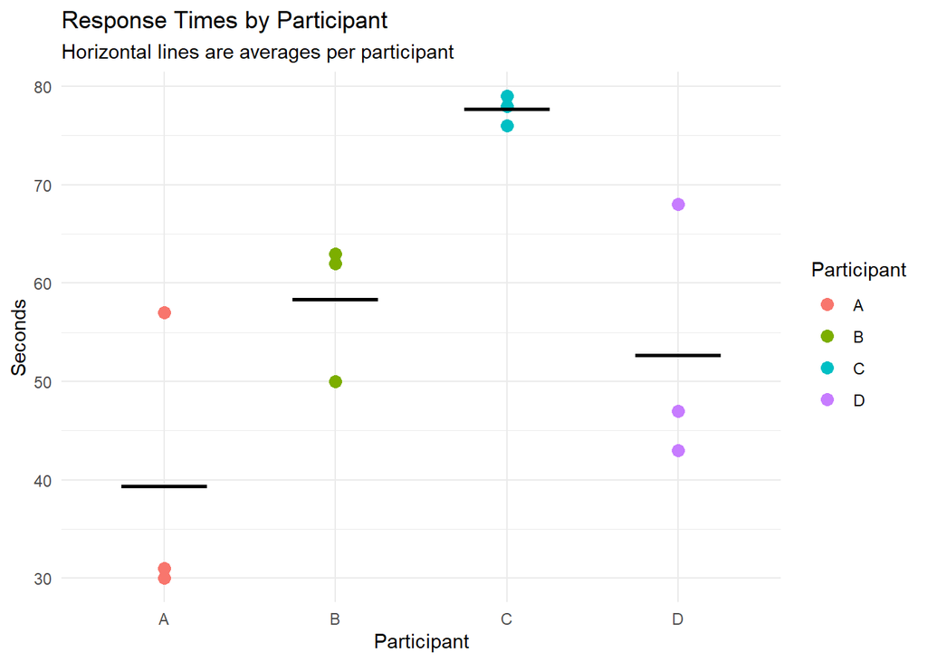

```r
# Summary data: mean line for each participant
participant_means <- rr %>%
  group_by(Individual) %>%
  summarise(mean_seconds = mean(Seconds, na.rm = TRUE), .groups = "drop")

# Plot
ggplot(rr, aes(x = Individual, y = Seconds, color = Individual)) +
  geom_point(size = 3) +
  geom_errorbar(
    data = participant_means,
    mapping = aes(x = Individual, ymin = mean_seconds, ymax = mean_seconds, color = Individual),
    inherit.aes = FALSE,
    width = 0.5,
    linewidth = 1,
    col="black"
  ) +
  scale_shape_manual(values = 0:25) +
  theme_minimal() +
  labs(
    title = "Response Times by Participant",
    subtitle = "Horizontal lines are averages per participant",
    y = "Seconds",
    x = "Participant",
    color = "Participant",
    shape = "Participant"
  )
```

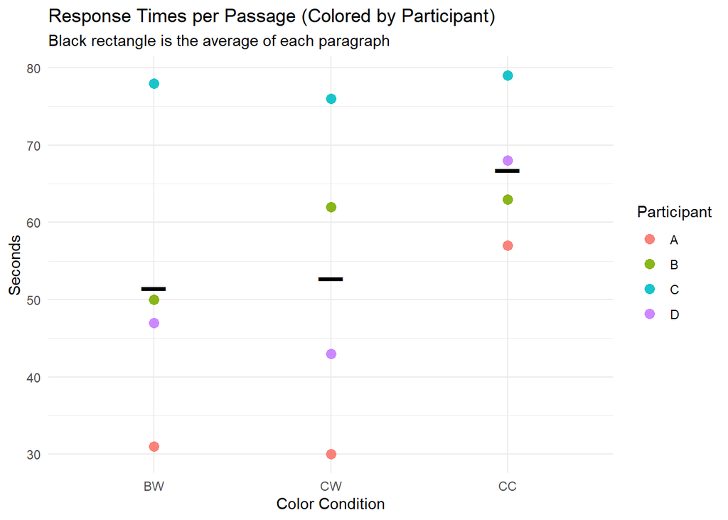

```r
ggplot(rr, aes(x = ColorCondition, y = Seconds)) +
  geom_point(aes(color = Individual), size = 3, alpha = 0.9) +
  stat_summary(fun = mean, geom = "point", shape = 95, size = 10, color = "black") +
  theme_minimal() +
  labs(
    title = "Response Times per Passage (Colored by Participant)",
    subtitle = "Black rectangle is the average of each paragraph",
    x = "Color Condition",
    y = "Seconds",
    color = "Participant"
  )
```

## Assumptions

```r
rr_aov <- aov(Seconds ~ Individual + ColorCondition, data = rr)

# Set model
model <- rr_aov  # Replace with your actual model object

# Extract residuals and fitted values
res <- residuals(model)
fit <- fitted(model)
n <- length(res)

# Residual dataframe (used in p1 and p3)
# !!! Grouping variable: Individual (Participant ID)
resid_df <- tibble(
  residuals = res,
  fitted = fit,
  order = 1:n,
  type = if ("Individual" %in% names(rr)) as.character(rr$Individual) else "All"
)

# QQ plot data
d <- tibble(
  x_sample = sort(res),
  z_theoretical = qnorm(ppoints(n))
)

# SE function for QQ bands
se_z <- function(z, n) sqrt((1 + z^2) / (2 * (n - 1)))

# QQ confidence band data
band <- tibble(
  z = seq(-2.2, 2.2, length.out = 300),
  n = n,
  sample_sd = sd(d$x_sample),
  se = sample_sd * se_z(z, n),
  line = mean(d$x_sample) + sample_sd * z,
  upper = line + 2 * se,
  lower = line - 2 * se,
  robust_sd = IQR(d$x_sample) / 1.349,
  robust_line = median(d$x_sample) + z * robust_sd,
  robust_se = robust_sd * se_z(z, n),
  robust_upper = robust_line + 2 * robust_se,
  robust_lower = robust_line - 2 * robust_se
)
```

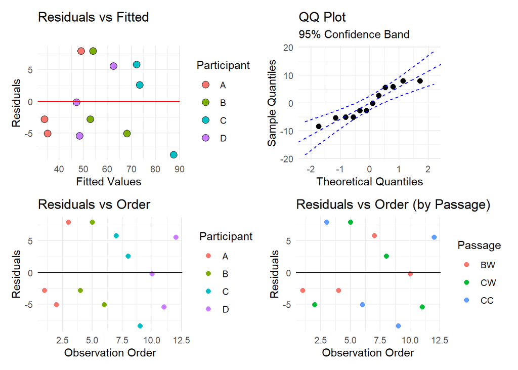

```r
# --- PLOTS ---

# 1. Residuals vs Fitted
p1 <- ggplot(resid_df, aes(x = fitted, y = residuals, fill = type)) +
  geom_point(shape = 21, color = "black", size = 3, stroke = 0.5) +
  geom_hline(yintercept = 0, color = "red") +
  theme_minimal() +
  labs(title = "Residuals vs Fitted", x = "Fitted Values", y = "Residuals", fill = "Participant")

# 2. QQ Plot
p2 <- ggplot(d) +
  geom_point(aes(x = z_theoretical, y = x_sample), size = 2.2) +
  geom_abline(
    aes(intercept = mean, slope = sd),
    data = tibble(mean = mean(d$x_sample), sd = sd(d$x_sample)),
    linetype = "dashed", color = "blue"
  ) +
  geom_line(aes(x = z, y = upper), data = band, linetype = "dashed", color = "blue") +
  geom_line(aes(x = z, y = lower), data = band, linetype = "dashed", color = "blue") +
  labs(
    x = "Theoretical Quantiles",
    y = "Sample Quantiles",
    title = "QQ Plot",
    subtitle = "95% Confidence Band"
  ) +
  theme_minimal()

# 3. Residuals vs Order
p3 <- ggplot(resid_df, aes(x = order, y = residuals, color = type)) +
  geom_point(size = 2) +
  geom_hline(yintercept = 0, color = "black") +
  theme_minimal() +
  labs(title = "Residuals vs Order", x = "Observation Order", y = "Residuals", color = "Participant")

# 4. Residuals vs Order (colored by Color Condition / Passage)
p4 <- ggplot(resid_df, aes(x = order, y = residuals, color = rr$ColorCondition)) +
  geom_point(size = 2) +
  geom_hline(yintercept = 0, color = "black") +
  theme_minimal() +
  labs(
    title = "Residuals vs Order (by Passage)",
    x = "Observation Order",
    y = "Residuals",
    color = "Passage"
  )

# Combine and show
(p1 + p2) / (p3 + p4)
```

### Residuals vs Fitted - Constant Variance Assumption

Our variance looks good. We do have some straggling data points at the beginning and end, but this is to be expected if our passages are giving different results for the passages.

### QQ Plot - Normally Distributed Residuals

The QQ plot suggests that the residuals are approximately normally distributed. Although there is a slight S-shaped curve that pushes the boundaries, all points lie close to the reference line and within the confidence bands. Therefore, we consider the normality assumption reasonably satisfied.

### Residuals vs Order - Independent Residuals

There are two Residual vs Order charts, one colored by individual and one by the passage. There is interestingly enough a ‘sin’ up and down curve to the data, but it may just be caused by the separation in how long it took for one specific passage to be read by the participant. It’s possible there is no pattern here. Either way, for now we will consider the requirement for independent residuals is met.

We can run our Anova.

## Anova and Analysis

```r
rr_aov <- aov(Seconds ~ Individual + ColorCondition, data = rr)
summary(rr_aov)
```

```
               Df Sum Sq Mean Sq F value  Pr(>F)
Individual      3 2279.3   759.8  12.484 0.00545 **
ColorCondition  2  573.5   286.7   4.712 0.05888 .
Residuals       6  365.2    60.9
---
Signif. codes:  0 '***' 0.001 '**' 0.01 '*' 0.05 '.' 0.1 ' ' 1
```

It’s not surprising that reader is significant with a p-value of .00545. Everybody reads at different speeds. It’s noteworthy that comprehension was not being tested, so what each participant considered as the paragraph being ‘read’ is different, but regardless this is not surprising. It is helpful to know, however, that a significant portion of unexplained variation was reduced by blocking the individuals, so our test is more accurate for Color Condition.

### Contrasts

Let’s run some contrasts to see if the colored text with white background is different from the colored text with a colored background. We will use Dunnet’s test to compare the ‘CW’ or colored on white against the ‘CC’ or colored on colored against the basic test paragraph to see if either is significantly different.

```r
emm <- emmeans(rr_aov, "ColorCondition")

# Compare each level to the control (level 0)
contrast(emm, method = "trt.vs.ctrl", ref = 1)  # if level 0 is the first level
```

```
 contrast estimate   SE df t.ratio p.value
 CW - BW      1.25 5.52  6   0.227  0.9544
 CC - BW     15.25 5.52  6   2.764  0.0596

Results are averaged over the levels of: Individual
P value adjustment: dunnettx method for 2 tests
```

We can see that we do not have sufficient evidence to conclude that the colored over white passage is different from normal text, but we almost have sufficient evidence for the colored on colored. It’s nearly as close as our anova p-value for Color Condition. This would suggest that it’s not just the colored text, but also the addition of the second changing and contrasting factor, the background.

## Conclusion

It’s not surprising that colors can be distracting and affect readability, but what is surprising is that this particular test is bordering the line of statistical significance. Further data collection with a larger and more diverse sample would help confirm whether the observed near-significant effect of colored backgrounds on reading speed reflects a true underlying difference.”

So does letter and background color have an effect on reading speed? It’s a strong maybe.